# Video Game Sales

```r
library(tidyverse)
```

```r
vgsales = read_csv("vgsales.csv")
head(vgsales)
```

| Rank | Name | Platform | Year | Genre | Publisher | NA_Sales | EU_Sales | JP_Sales | Other_Sales | Global_Sales |
| --- | --- | --- | --- | --- | --- | --- | --- | --- | --- | --- |
| 1 | Wii Sports | Wii | 2006 | Sports | Nintendo | 41.49 | 29.02 | 3.77 | 8.46 | 82.74 |
| 2 | Super Mario Bros. | NES | 1985 | Platform | Nintendo | 29.08 | 3.58 | 6.81 | 0.77 | 40.24 |
| 3 | Mario Kart Wii | Wii | 2008 | Racing | Nintendo | 15.85 | 12.88 | 3.79 | 3.31 | 35.82 |
| 4 | Wii Sports Resort | Wii | 2009 | Sports | Nintendo | 15.75 | 11.01 | 3.28 | 2.96 | 33.00 |
| 5 | Pokemon Red/Pokemon Blue | GB | 1996 | Role-Playing | Nintendo | 11.27 | 8.89 | 10.22 | 1.00 | 31.37 |
| 6 | Tetris | GB | 1989 | Puzzle | Nintendo | 23.20 | 2.26 | 4.22 | 0.58 | 30.26 |

# Game Genre Analysis

## NA Sales by Genre

Action and sport games are the most sold game genres in North America.

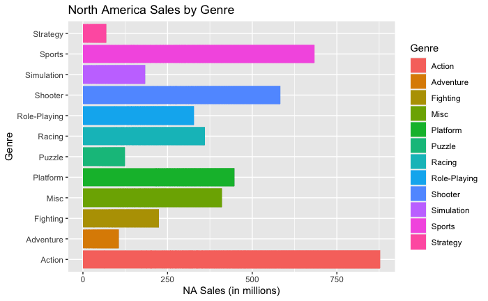

```r
vgsales %>%
  ggplot(aes(x=NA_Sales, y=Genre)) +
  geom_col(aes(fill=Genre)) +
  xlab("NA Sales (in millions)") +
  ylab("Genre") +
  ggtitle("North America Sales by Genre ")
```

## EU Sales by Genre

Action and sport games are the most sold game genres in Europe.

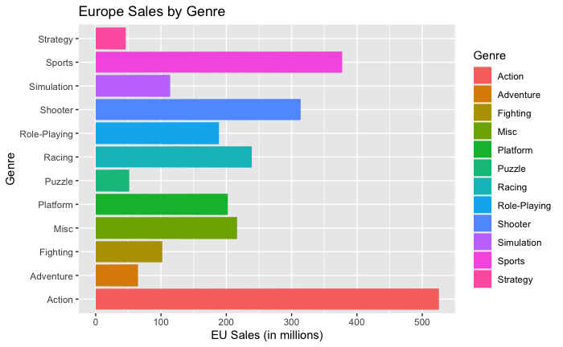

```r
vgsales %>%
  ggplot(aes(x=EU_Sales, y=Genre)) +
  geom_col(aes(fill=Genre)) +
  xlab("EU Sales (in millions)") +
  ylab("Genre") +
  ggtitle("Europe Sales by Genre ")
```

## JP Sales by Genre

Role-playing and action games are the most sold game genres in Japan.

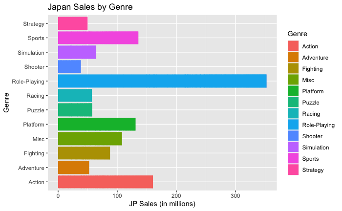

```r
vgsales %>%
  ggplot(aes(x=JP_Sales, y=Genre)) +
  geom_col(aes(fill=Genre)) +
  xlab("JP Sales (in millions)") +
  ylab("Genre") +
  ggtitle("Japan Sales by Genre ")
```

## Other Regions Sales by Genre

Action and sport games are the most sold genres in other regions.

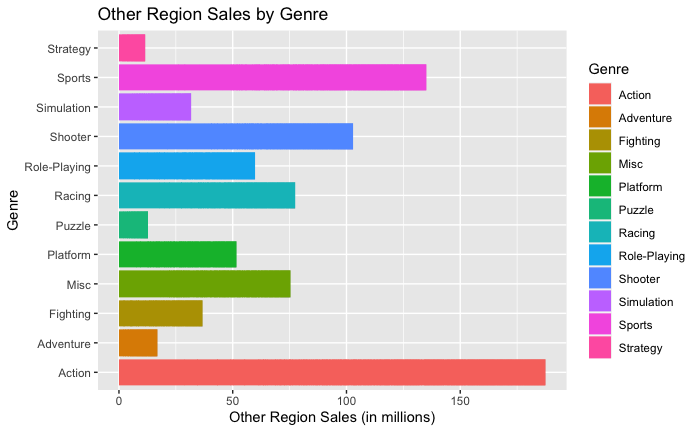

```r
vgsales %>%
  ggplot(aes(x=Other_Sales, y=Genre)) +
  geom_col(aes(fill=Genre)) +
  xlab("Other Region Sales (in millions)") +
  ylab("Genre") +
  ggtitle("Other Region Sales by Genre ")
```

## Regional Sales by Genre (Side-by-Side)

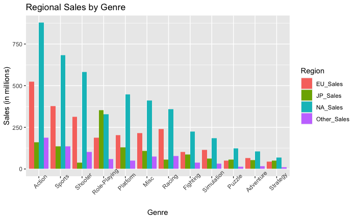

```r
vgsales %>%
  select(Genre, NA_Sales, EU_Sales, JP_Sales, Other_Sales) %>%
  group_by(Genre) %>%
  summarize(NA_Sales=sum(NA_Sales), EU_Sales=sum(EU_Sales),
            JP_Sales=sum(JP_Sales), Other_Sales=sum(Other_Sales)) %>%
  pivot_longer(cols=2:5, names_to="Region", values_to="sales") %>%
  ggplot(aes(x=reorder(Genre, -sales), y=sales)) +
  geom_col(aes(fill=Region), position="dodge") +
  theme(axis.text.x = element_text(angle=45)) +
  xlab("Genre") +
  ylab("Sales (in millions)") +
  ggtitle("Regional Sales by Genre")
```

## Global Sales by Genre

Action and sport games are the most sold genres globally.

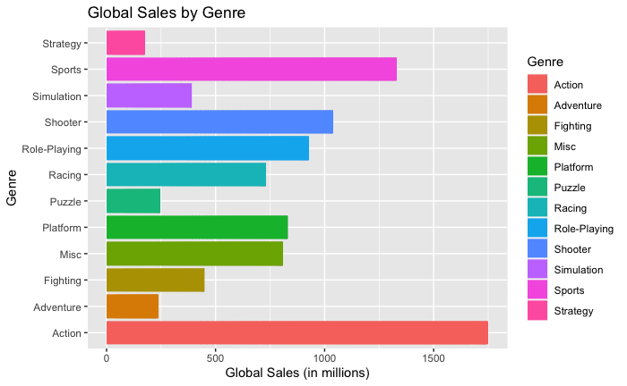

```r
vgsales %>%
  ggplot(aes(x=Global_Sales, y=Genre)) +
  geom_col(aes(fill=Genre)) +
  xlab("Global Sales (in millions)") +
  ylab("Genre") +
  ggtitle("Global Sales by Genre ")
```

## Which game genre is most frequent?

Action and sport games appear the most within this dataset.

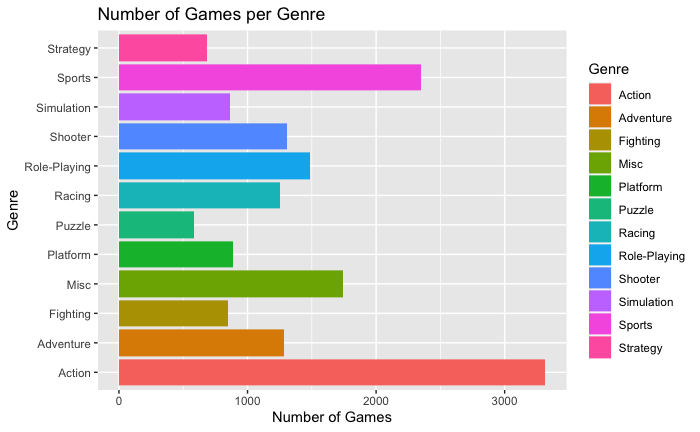

```r
vgsales %>%
  group_by(Genre) %>%
  summarize(count = n()) %>%
  ggplot(aes(x=count, y=Genre)) +
  geom_col(aes(fill=Genre)) +
  xlab("Number of Games") +
  ylab("Genre") +
  ggtitle("Number of Games per Genre")
```

## Which game genre was sold the most globally in a single year?

Action was the most sold game genre globally in 2009 for 139.36 million.

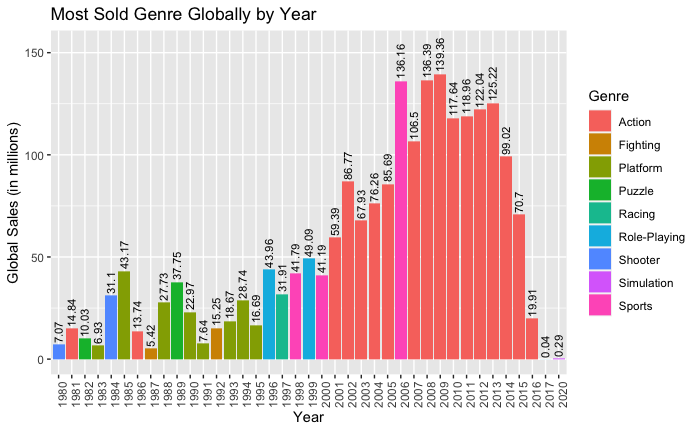

```r
year_genre_sales = vgsales %>%
  select(Genre, Year, Global_Sales) %>%
  group_by(Genre, Year) %>%
  summarize(sales=sum(Global_Sales))
year_max = year_genre_sales %>%
  group_by(Year) %>%
  summarize(max_sales=max(sales))

year_genre_max = right_join(year_max, year_genre_sales) %>%
  filter(max_sales == sales) %>%
  head(-1) %>%
  select(Year, Genre, max_sales)
year_genre_max %>%
  ggplot(aes(x=Year, y=max_sales)) +
  geom_col(aes(fill=Genre)) +
  geom_text(aes(label=max_sales), size=3, angle=90, hjust=-0.08) +
  theme(axis.text.x = element_text(angle=90)) +
  ylim(0, max(year_genre_max$max_sales) * 1.1) +
  xlab("Year") +
  ylab("Global Sales (in millions)") +
  ggtitle("Most Sold Genre Globally by Year")
```

# More Global Sales Analysis

## Global Sales over the Years

Global sales for video games steadily increased up until around 2007, and has since steadily decreased up until 2020.

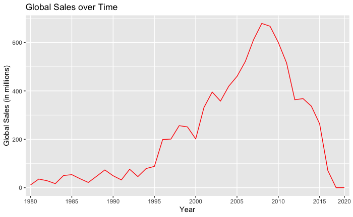

```r
vgsales %>%
  group_by(Year) %>%
  summarize(sales=sum(Global_Sales)) %>%
  head(-1) %>%
  ggplot(aes(x=Year, y=sales, group=1)) +
  geom_line(color="red") +
  scale_x_discrete(breaks=c(1980, 1985, 1990, 1995, 2000, 2005, 2010, 2015, 2020)) +
  xlab("Year") +
  ylab("Global Sales (in millions)") +
  ggtitle("Global Sales over Time")
```

## Which platform has the most sales globally?

The PS2 platform has the highest number of sales globally.

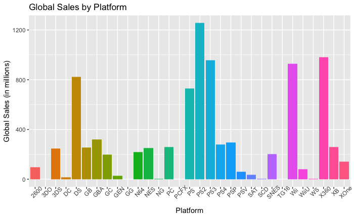

```r
vgsales %>%
  group_by(Platform) %>%
  summarize(sales = sum(Global_Sales)) %>%
  ggplot(aes(x=Platform, y=sales)) +
  geom_col(aes(fill=Platform), show.legend = FALSE) +
  theme(axis.text.x = element_text(angle=45)) +
  xlab("Platform") +
  ylab("Global Sales (in millions)") +
  ggtitle("Global Sales by Platform")
```

## Which publisher has the most sales globally?

The publisher Nintendo has the highest number of sales globally, followed by Electronic Arts.

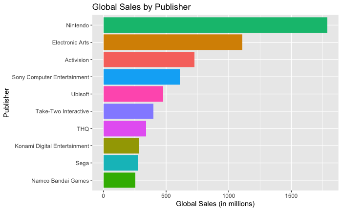

```r
vgsales %>%
  group_by(Publisher) %>%
  summarize(sales = sum(Global_Sales)) %>%
  arrange(desc(sales)) %>%
  top_n(10) %>%
  ggplot(aes(x=reorder(Publisher, sales), y=sales)) +
  geom_col(aes(fill=Publisher), show.legend = FALSE) +
  xlab("Publisher") +
  ylab("Global Sales (in millions)") +
  ggtitle("Global Sales by Publisher") +
  coord_flip()
```

# Publisher Analysis

## What are the top 10 publishers based on game production?

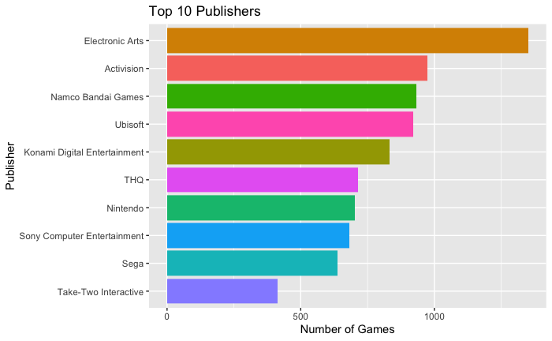

```r
vgsales %>%
  group_by(Publisher) %>%
  summarize(count = n()) %>%
  arrange(desc(count)) %>%
  top_n(10) %>%
  ggplot(aes(x=reorder(Publisher, count), y=count)) +
  geom_col(aes(fill=Publisher), show.legend=FALSE) +
  xlab("Publisher") +
  ylab("Number of Games") +
  ggtitle("Top 10 Publishers") +
  coord_flip()
```

## Who is/are the top publisher(s) based on regional sales?

Video games published by Nintendo have the highest sales in North America, Europe, and Japan. Video games published by Electronic Arts have the highest sales in other regions.

```r
publisher_region_sales = vgsales %>%
  group_by(Publisher) %>%
  summarize(NA_Sales=sum(NA_Sales), EU_Sales=sum(EU_Sales),
            JP_Sales=sum(JP_Sales), Other_Sales=sum(Other_Sales)) %>%
  pivot_longer(cols=2:5, names_to="Region", values_to="Sales")

region_sales = publisher_region_sales %>%
  group_by(Region) %>%
  summarize(Max_Sales=max(Sales))

publisher_region_max = right_join(publisher_region_sales, region_sales, by="Region") %>%
  filter(Max_Sales == Sales) %>%
  select(Publisher, Region, Max_Sales) %>%
  arrange(desc(Max_Sales))

publisher_region_max
```

| Publisher | Region | Max_Sales |
| --- | --- | --- |
| Nintendo | NA_Sales | 816.87 |
| Nintendo | JP_Sales | 455.42 |
| Nintendo | EU_Sales | 418.74 |
| Electronic Arts | Other_Sales | 129.77 |

```r
NA
```

## How does the global sales of Nintendo compare to Electronic Arts over the years?

Nintendo’s global sales tends to be greater than Electronic Arts, with the exception of a few years in the early 2000s. Nintendo’s global sales experienced a large increase from 2003 to 2006, however, in the more recent years, Electronic Arts’ global sales seem to be greater than Nintendo’s.

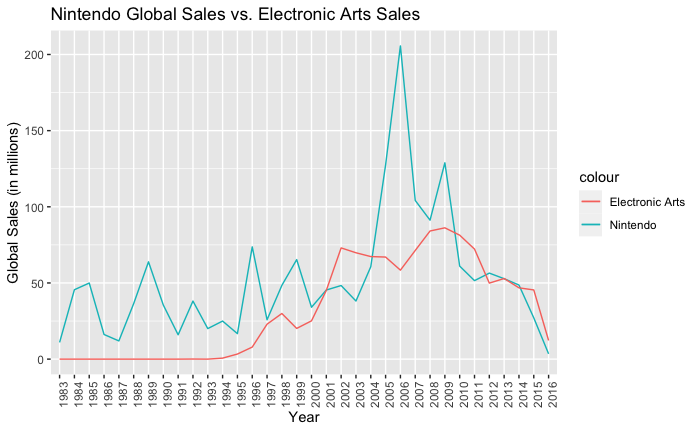

```r
vgsales %>%
  filter(Publisher == "Electronic Arts" | Publisher == "Nintendo") %>%
  group_by(Year, Publisher) %>%
  summarize(Global_Sales = sum(Global_Sales)) %>%
  head(-2) %>%
  pivot_wider(names_from="Publisher", values_from="Global_Sales") %>%
  rename("Electronic_Arts" = "Electronic Arts") %>%
  mutate(Electronic_Arts = replace_na(Electronic_Arts, replace=0)) %>%
  ggplot(aes(x=Year, group=1)) +
  geom_line(aes(y=Nintendo, color="Nintendo")) +
  geom_line(aes(y=Electronic_Arts, color="Electronic Arts")) +
  theme(axis.text.x = element_text(angle=90)) +
  xlab("Year") +
  ylab("Global Sales (in millions)") +
  ggtitle("Nintendo Global Sales vs. Electronic Arts Sales")
```

## What game genres are the most produced by Electronic Arts and Nintendo?

Sport games largely dominate as the most produced game genre by Electronic Arts, whereas Nintendo game genre production is very diverse with platform games as the most produced, followed closely by role-playing games, then miscellaneous.

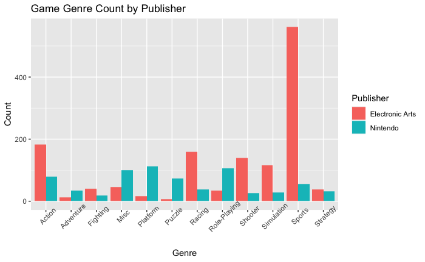

```r
vgsales %>%
  filter(Publisher == "Electronic Arts" | Publisher == "Nintendo") %>%
  group_by(Genre, Publisher) %>%
  summarize(Count = n()) %>%
  ggplot(aes(x=Genre, y=Count, fill=Publisher)) +
  geom_col(aes(),position="dodge") +
  theme(axis.text.x = element_text(angle=45)) +
  ggtitle("Game Genre Count by Publisher")
```

```r
NA
```

# Total Sales Analysis

## Which region sells the most amount of video games?

North America has the most sales of video games.

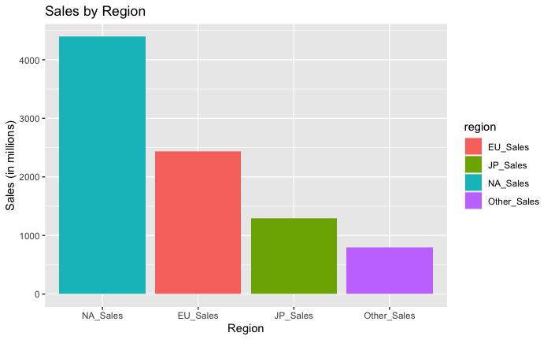

```r
vgsales %>%
  select(NA_Sales, EU_Sales, JP_Sales, Other_Sales) %>%
  summarize(NA_Sales=sum(NA_Sales), EU_Sales=sum(EU_Sales),
            JP_Sales=sum(JP_Sales), Other_Sales=sum(Other_Sales)) %>%
  pivot_longer(cols=1:4, names_to="region", values_to="sales") %>%
  ggplot(aes(x=reorder(region, -sales), y=sales)) +
  geom_col(aes(fill=region)) +
  xlab("Region") +
  ylab("Sales (in millions)") +
  ggtitle("Sales by Region")
```

## Which year had the most sales for each region?

North America had the highest number of sales in 2008. Europe had the highest number of sales in 2009. Japan had the highest number of sales in 2006. Other regions had the highest number of sales in 2008.

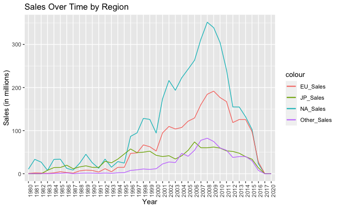

```r
vgsales %>%
  select(Year, NA_Sales, EU_Sales, JP_Sales, Other_Sales) %>%
  group_by(Year) %>%
  summarize(NA_Sales=sum(NA_Sales), EU_Sales=sum(EU_Sales),
            JP_Sales=sum(JP_Sales), Other_Sales=sum(Other_Sales)) %>%
  head(-1) %>%
  ggplot(aes(x=Year, group=1)) +
  geom_line(aes(y=NA_Sales, color="NA_Sales")) +
  geom_line(aes(y=EU_Sales, color="EU_Sales")) +
  geom_line(aes(y=JP_Sales, color="JP_Sales")) +
  geom_line(aes(y=Other_Sales, color="Other_Sales")) +
  theme(axis.text.x = element_text(angle=90)) +
  xlab("Year") +
  ylab("Sales (in millions)") +
  ggtitle("Sales Over Time by Region")
```